# Spatial Simulation: Exploring Pattern and Process

Joseph Lewis

22 March 2020

# Purpose and Aims

Work my through the Spatial Simulation: Exploring Pattern and Process book by David O’Sullivan and George L.W. Perry. This is to formally develop my experience in spatial simulation, as well as record my learnings.

To aid this development, I will use R. Wherever possible, I will aim to use randomly generated data. This is to ensure that the fundamentals are learned, and can be generalised to other datasets.

# Chapter One: Spatial Simulation Models: What? Why? How?

Scientific models (e.g. spatial simulation models) are simplified representations of the world that are deliberately developed with the particular purpose of exploring aspects of the world around us (p.1).

Two different views for models:

- models as primarily exploratory or heuristic learning tools, which we can use to clarify our thinking about the world, and to prompt further questions and further exploration (this is a product of the types of system and types of problem encountered in the social and environmental sciences)(p.2).
- models as primarily predictive tools (traditional view)

## 1.1 What are Simulations models?

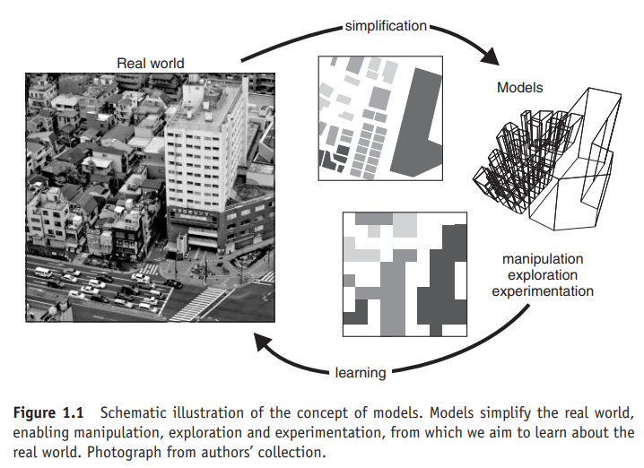

Scientific models are a simplified representation of a system under study, which can be used to explore, to understand better or to predict the behaviour of the system it represents (p. 3).

The process of model development demands that we simplify from the often bewildering complexity of the real world by deciding what matters (and what does not) in the context of the current investigation (p. 4).

The first step in any modelling exercise is the development of a conceptual model.

- Approaching the phenomenon under study from a particular theoretical perspective will bring a variety of abstract concepts into play, and these will inform how the system is broken down into its constituent elements in systems analysis.
- Systems analysis is a method by which we simplify a phenomenon of interest by systematically breaking it down into more manageable elements to develop a conceptual model.

In the systems analysis process, we typically break a real-world phenomenon or system down into general elements:

- **Components** are the distinct parts or entities that make up the system (e.g. trees)
- **State variables** are individual component or whole-system level measures or attributes that enable us to describe the overall condition of the system at a particular point in space or moment in time (e.g. Total forest biomass instead of the biomass individual trees and other plant species).
- **Processes** are the mechanisms by which the system and its components make the transition from one state to another over time. Processes dictate how the values of the involved components’ state variables change over time.
- **Interactions** between the system components. In the context of spatial simulation, interactions are more likely and/or stronger between components that are near one another in space, making a spatially explicit model desirable.

A conceptual model can be converted to a mathematical model (i.e. computer/simulation model) where component states are represented by variables and the relationships between them by mathematical equations.

- The relationships and equations governing the behaviour of a model are captured in a computer model or simulation model. The simulation model can then be used to explore how the system changes when assumptions about how it works or the conditions in which it is set are altered.

In a simulation model, a computer is programmed to iteratively recalculate the modelled system state as it changes over time in accordance with the relationships represented by the mathematical and other relationships that describe the system. The most widely used simulation models are systems dynamics models.

- **stocks** are system variables that represent quantities stored in the system over time (e.g. population).
- **Flows** represent the movement of stock variables among different parts of the system (e.g. births ‘flowing’ into the population or deaths leaving the population).
- **Parameters** describe the overall state of the system and govern the relationships among stocks and flows (e.g. rate of population growth).

Systems dynamics models are effectively computer simulations of mathematical models consisting of interrelated differential equations, although they often also include empirically derived relationships and semi-quantitative ‘rules’.

In Spatially explicit model we decide that representing distinct spatial elements and their relationships is important for a full understanding of the system. Thus, a spatially explicit model has elements representing individual regions of geographical space or individual enities located in space (such as trees, animals, humans, cities and so on). Each region and entity has its own set of state variables and interacts continuously through time with other regions and entities, typically interacting more strongly with those objects that are nearest to it. These interactions may be governed by mathematical equations, by logical rules or by other mechanisms, and they directly represent mechanisms that are thought to operate in the real-world system represented by the simulation.

## 1.2 How do we use simulation models?

Systems for which we have reliable, detailed data and whose underlying mechanisms we understand well are the ones most suitable for predictive modelling.

**Using models for prediction**

The lack of data or of good understanding of the field in question are reasons for being cautious about prediction. It is also important to be wary of the prospects for prediction in contexts where although individual elements are well understood, the aggregation of many interacting elements can lead to unexpected nonlinear effects.

**Models as guides to data collection**

Where the most pressing deficits in our knowledge of systems are empirical, so that we lack good observational data about actual behaviour, the most important role for models may be to help us decide which data are most critical to improving our understanding.

If the underlying processes can be modelled, then we can perform sensitivity analysis on the models to find out which parameters have the strongest effect on the likely outcomes. The data most essential to improving our ability to forecast outcomes more reliably can be colected.

- e.g. For endangered animals we may not have reliable data on their populations, but we do have good general frameworks for modelling population dynamics (for example Lande et al., 2003). Applying such models to endangered species with best guess estimates of critical parameters and the associated uncertainties may help conservation workers to target future data collection on the critical features of the system, and also to design improved management schemes

**Models as ‘tools to think with’**

No shortage of empirical data, but we have limited understanding of how a system works. Simulation models can become ‘tools for thought’.

Simulation models that represent whatever working hypotheses we have about the target system and then experiment on the model to see what the implications of those theories and hypotheses might be in the real world.

However, it is beset by the equifinality problem, which refers to the fact that large numbers (in fact an infinite number) of possible models, including the same model with different input data, could produce behaviour consistent with observational data. Identifying the processes responsible for a given pattern, on the basis of that pattern alone, is problematic.

## 1.3 Why do we use simulation models?

Some systems of interest to social and environmental scientists are not amenable to experiment for rather prosaic reasons. Archaeologists, anthropologists and palaeontologists are interested in systems that no longer exist.

## 1.4 Modelling observational data using probability distributions

**An additive process: the normal (Gaussian) distribution**

Approximately Gaussian distributions arise as the result of a series of independent additive processes, as explained by the (additive) central limit theorem.

**Multiplicative processes: various skewed distributions**

A different distribution will arise in systems dominated by multiplicative processes (e.g. lognormal distribution). Lognormal is not the only distribution generated by multiplicative processes. Zipf, Pareto and power-law distributions can also occur.

Many (perhaps most) processes in environmental and social systems are multiplicative rather than additive (e.g. population growth is multiplicative).

The key idea behind this book is that if we are alert to the similarities between patterns across diverse domains then perhaps the loss of generality as we move from abstract to more specific models can be mitigated to a degree.

e.g. visitors to an art gallery looking for a celebrated work of art and caribou searching for food in the tundra are clearly very different, but is there any commonality in these’foraging’ processes that means we can, at least in the first instance, think about their representation in the same way?

Many ostensibly different spatial patterns, arising in very different systems, can usefully be represented using similar frameworks.

Developing detailed, dynamic, spatial models comes at some cost in generality and interpretability, but buys us realism and the ability to represent specific processes in specific contexts.

# Chapter Two: Pattern, Process and Scale

The processes that are dominant in a system leave distinctive fingerprints in the form of dynamic spatial patterns. However, While the careful characterisation of pattern in a system can help us to identify candidate driving processes or, perhaps more realistically, rule out less important ones, it cannot unequivocally isolate the processes responsible for the observed patterns.

There are also difficult issues related to the scales at which we detect and perceive patterns, how patterns change with scale and the inferences we can make at scales different from those at which we have made observations.

## 2.1 Thinking about spatiotemporal patterns and processes

**What is a pattern?**

patterns are the discernible outcomes or signatures of the processes operating in a given system - defining characteristics of a system and often, therefore, indicators of essential underlying processes and structures.

Spatial patterns can be represented using a range of data models:

- Point-reference (geostatistical) data
- Areal data
- Point process data

**What is a process?**

The spatial and temporal patterns that we observe in the systems we are investigating are the outcomes of the processes operating in those systems - The process is any mechanism that causes a system to change its state, and so potentially to produce characteristic patterns.

Processes generate patterns, but patterns are the outcomes of processes and can suppress or amplify those same proceses.

**Scale**

Scale colours any consideration of pattern and process-it affects how we perceive pattern, how we represent process and how each affects the other - scale denotes the resolution within the range or extent of a measured quantity.

In the context of spatial analysis and modelling, scale can be decomposed into grain and extent:

- Spatially, grain refers to the resolution of the data.
- Spatially, extent refers to the total area that the dataset spans.

scale-dependence: the patterns that we perceive in a given system are a function of the space- time scale at which we view it.

Some patterns (i.e. fractal) do not change with scale-that is, they are not scale-dependent -

Processes can also be scale-dependent - A particular process will likely reveal its effects most strongly across a limited range of scales, and so as we change the scale at which we look at a system the dominant suite of processes will shift.

Processes that occur rapidly but whose effects are felt much more slowly are particularly difficult to pin down.

## 2.2 Using models to explore spatial patterns and processes

Phenomenological models emphasise reproducing observed patterns and not the mechanisms responsible for generating them.

Mechanistic models are more concerned with the underlying processes, using functions and distributions based on theoretical expectation.

**Characterising Point patterns: first- and second-order structure**

First-order structure relates to general (global) trends, such as, for example, variation in the density (or intensity) of events across a plot as a function of some underlying covariate. In a pattern solely structured by first-order effects the location of any individual event is independent of the location of other events in the pattern (i.e. non-stationary or inhomogeneous patterns).

If the location of events is influenced by that of other events-that is, the events interact in some way-this is termed second-order structure.

Teasing the two effects apart, while difficult, is important because the types of mechanisms generating the two effects are different and so the inferences we might draw about generating process are also different.

If we can characterise a pattern by separating out first- and second-order components, then the direct link to the types of processes responsible might allow us to rule out some possibilities even if we remain unable to isolate the specific generating mechanisms responsible for the pattern.

**Using null models to evaluate patterns**

We often want to know how well our data match what we would expect if a given null model (often complete spatial randomness) described the data adequately.

Deciding on an appropriate null model is important: in spatial analysis a model of CSR is often used but this is a limited approach.

If we want to tease such effects apart we need to use a null model that includes first- but not second-order structure. Rejection of that null model would allow us to evaluate the extent to which first-order structure alone accounts for any observed aggregation.

A second key step in this procedure is deciding on a summary measure of the data to compare with the null model. Ideally we want a statistic that effectively summarises all the detail in the data-a so-called sufficient statistic.

- the use of a summary measure is necessary because it is impractical to compare all the information we have when using complex simulation models that generate dynamic spatial outcomes.

```r
library(spatstat)
```

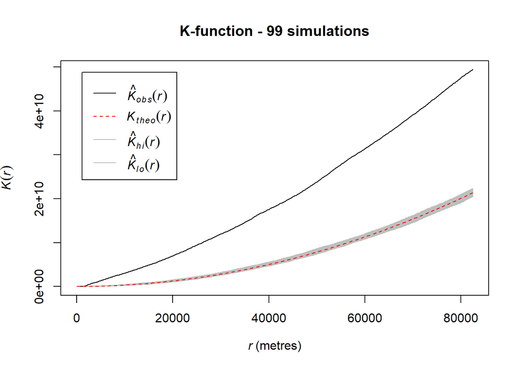

```r
plot(envelope(murchison$gold, Kest, nsim = 99, verbose = FALSE), main = "K-function - 99 simulations")
```

CSR model does not adequately describe the data. K(r) is above the CSR envelope and suggests that the locations of Murchison gold are clustered.However, the use of CSR as the null hypothesis does not identify first-an second-order effects.

**Density-based (first-order) null models**

The basic null model for point patterns is CSR, known more formally as the homogeneous Poisson process.

CSR follows a Poisson distribution. We can estimate the intensity as the number of events in the pattern divided by the focal area (i.e. divided by the density).

Simulating a realisation of the homogeneous Poisson process is straightforward: simply draw an (x, y) coordinate pair for each event from a uniform distribution.

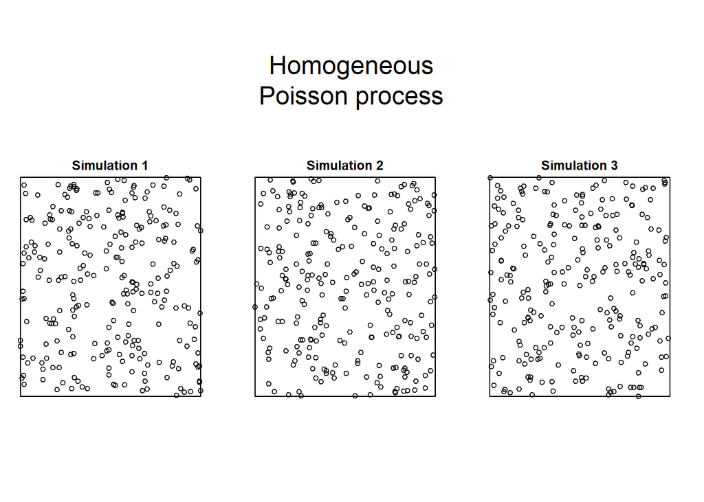

```r
plot(runifpoint(n = murchison$gold$n, win = murchison$gold$window, nsim = 3), main = "Homogeneous\nPoisson process")
```

However, we expect the underlying intensity (number of events in the pattern divided by the focal area) of the process to vary across space (e.g plants may respond to variability in soil nutrient and water availability so that their density varies in space).